# S1.3c — BL-077: c’è matrice fra le cellule? Misura dai conteggi a 2 µm

geo_spatialtrans — report di step

Published

October 14, 2026

# Sintesi

**Domanda** (BL-077). Il simulatore assume che ogni punto di una regione di tessuto appartenga a una cellula: la cellula è il suo territorio di Voronoi, senza matrice fra le cellule (decisione 1 del design). Ci sono, nei dati reali, zone di tessuto senza cellule? E se sì, stanno attorno a ogni cellula (A: corpo cellulare più piccolo del territorio) o a chiazze (B: generatori acellulari)?

**Metodo.** Sui 30 ROI di R2 (5 per archetipo A1–A6) si contano le finestre di 6 µm di tessuto con tanti UMI quanti il vetro lontano dalla sezione, e si confrontano con quante ne produce il simulatore attuale sugli stessi nuclei (permutazione dei bin dentro ogni territorio). L’eccesso è E.

**Risultati.**

1. **Nessuna zona vuota rilevata.** E < 0.05 in tutti i 30 ROI e in tutte le varianti (massimo 0.033). La regola pre-registrata dà formalmente C («lasciare e dichiarare il limite»).
2. **Ma la misura è cieca.** (a) Nei lumi veri (A1–A4) i bin non scendono al livello del vetro lontano: a 16–32 µm dal bordo del tessuto restano 4.41–10.86 volte sopra (mediane per archetipo); il revisore ha mostrato che la stessa coda lunga c’è anche sul vetro fuori dalla sezione (diffusione), e che la soglia «vetro ≥ 50 µm» la esclude per costruzione. (b) Anche un vuoto sintetico **perfetto** è recuperato solo in parte: E rileva vuoti ≥ 10–20 % dell’area (A4 tipo A: nemmeno al 30 %). Quindi «nessuna zona vuota» **non** significa «nessuna matrice»: con i soli conteggi a 2 µm la matrice fra le cellule non è distinguibile.
3. **Risultato positivo inatteso: l’RNA è concentrato vicino al nucleo in A5 (cervello) e A6 (cuore).** Il rapporto R fra UMI a 4–8 µm e UMI sul nucleo vale 0.59 e 0.63, contro 0.90 e 0.98 previsti dal simulatore attuale; nuclei traslati a caso lo riportano vicino a 1, e (revisione) resiste lontano dai bordi. In A1–A3 il calo osservato è già prodotto dal simulatore attuale (forma dei territori e bordi).
4. **Difetto a monte.** La maschera di tessuto di R2 scarta tessuto pallido ma vero: neuropilo in A5 (luminosità > 0.97, ~12 % del ROI) e parte del miocardio in A6 (2 ROI su 5). Tocca anche le densità per area di R2/R3 in A5/A6.

**Conseguenze.** La decisione 1 resta in vigore per difetto, non per evidenza; BL-077 resta aperta e richiede un’altra misura (istologia annotata, o un modello della diffusione da R5). Il gradiente nucleo → periferia va in S1.4 (`derive_cell_geometry()`). **Stato: non chiusa** — la domanda non trova risposta con questi dati; tutto il lavoro e il motivo sono documentati.

# 1. Pre-registrazione

Testo: `results/S1.3c/S1.3c_preregistration.md` (commit `f341f71`, approvato da Luca il 2026-10-12, «va bene»; correzione del criterio di forma approvata prima del run, «Approvo la correzione»). Definizioni operative, deviazioni e post hoc, con data e posizione rispetto al run: `results/S1.3c/S1.3c_dev_notes.md`.

| Elemento | Attesa / regola | Fonte |
| --- | --- | --- |
| Misura | φ_obs = frazione di finestre 6×6 µm (sensibilità 10) di tessuto valido con UMI ≤ q95 delle finestre di vetro a ≥ 50 µm dal tessuto | prereg. §3 |
| Nullo | permutazione dei bin dentro il territorio R3 (20 seed) → φ_null; E = φ_obs − φ_null | prereg. §3 |
| Regola | E < 0.05 → nessuno; altrimenti A (BA ≥ 0.75), B (BA < 0.65 e ≥ 50 % del vuoto in componenti > territorio mediano), indeterminato; nessun E ≥ 0.05 → C | prereg. §4–5; 0.05 = convenzione |
| P1–P5 | A4 E minima e < 0.05; A3 E ≥ 0.05 con B; E(A1) ≤ E(A2) < E(A3); A5 A più probabile di B; A6 E < 0.05 senza B | B-043…B-085 |

**Deviazioni dichiarate** (dettaglio nelle note):

1. Prima del run: geni della matrice filtrata come primaria (decisione di Luca dopo C-3, «Geni comuni come primaria»); prova su A4 f1 con un difetto corretto.
2. Dopo la revisione: correzione del conteggio di CP-1 (M-01), applicazione dello spostamento ottimo di C-2 dove FAIL come pre-registrato (M-02), mappatura sulle maschere a 1/4 (RC-2), R sotto il nullo (M-05), gestione delle BA non definite (M-14), `tools/S1.3c_analysis.py` scritto durante il run e committato dopo (M-15). Verdetti invariati.
3. Post hoc PH-1…PH-4 dichiarate dopo la lettura dei risultati.

# 2. Check C — correttezza software

```r
tabc <- as.data.frame.matrix(table(CC$check, factor(CC$status, levels = c("PASS", "WARN", "FAIL"))))
kable(cbind(check = rownames(tabc), tabc), row.names = FALSE)
```

| check | PASS | WARN | FAIL |
| --- | --- | --- | --- |
| C-1 | 30 | 0 | 0 |
| C-2 | 16 | 4 | 10 |
| C-3 (geni comuni, primaria) | 5 | 0 | 0 |
| C-3 (pre-registrato, tutti i geni) | 0 | 0 | 5 |
| C-4 | 30 | 0 | 0 |
| C-5a | 6 | 0 | 0 |
| C-5b (tipo A) | 3 | 0 | 3 |
| C-5c (tipo B) | 3 | 0 | 3 |
| sfondo (all, k=3) | 5 | 0 | 0 |
| sfondo (all, k=5) | 5 | 0 | 0 |
| sfondo (com, k=3) | 5 | 0 | 0 |
| sfondo (com, k=5) | 5 | 0 | 0 |

- **Test unitari**: `R/testing/test_S1.3c.py` 31/31 (modulo di misura); `tools/S1.3c_analysis.py --test` 8/8 (aggregazione e regola, aggiunto dopo M-01).
- **C-1** 30/30; **C-4** 30/30 (il mutante permuta i bin di tessuto valido del ROI ignorando i territori e viola i totali).
- **C-3** pre-registrato FAIL 5/5 per definizione (grezza e filtrata hanno insiemi di geni diversi); sui geni della filtrata grezza = filtrata in 5/5. Geni esclusi: 0.1 % (A5) – 7.6 % (A1) degli UMI.
- **C-6** PASS: catena completa rieseguita da zero dopo le correzioni, 196 file con md5 identici.
- **C-2 registrazione**: 16 PASS, 4 WARN, 10 FAIL. PH-2 (due metà indipendenti di ogni ROI): A4 e A6 a (0, 0) salvo A6 r4 (−2, 0); A5 tra 0 e 4 µm, riproducibile; in A2 gli ottimi delle due metà distano 8–15 µm e la correlazione a (0, 0) è ≤ 0.021 in r1–r3 (0.05 e 0.11 in r4, r5): i FAIL di A2 sono rumore dello stimatore, non uno spostamento dimostrato. Il revisore, con ricerca fino a ±30 µm, trova l’ottimo entro ±8 µm in 30/30. Lo spostamento ottimo è applicato (come pre-registrato) a BA, R e CP-1 nei 10 ROI con FAIL; E non dipende dalla registrazione.

```r
d <- CC[CC$check == "C-2", c("unit", "value", "status")]
ph <- PH2; ph$unit <- paste(ph$archetype, ph$roi_id, sep = "_")
d <- merge(d, ph[, c("unit", "best_h0", "best_h1", "halves_dist_um")], by = "unit", sort = FALSE)
kable(d, col.names = c("ROI", "ottimo (dx, dy) µm, |r| (a 0)", "C-2", "ottimo metà 0", "ottimo metà 1", "distanza fra metà (µm)"), row.names = FALSE)
```

| ROI | ottimo (dx, dy) µm, \|r\| (a 0) | C-2 | ottimo metà 0 | ottimo metà 1 | distanza fra metà (µm) |
| --- | --- | --- | --- | --- | --- |
| A1_r1 | (4, 6) um, r 0.189 (a 0: 0.135) | FAIL | (4, 6) | (4, 4) | 2.000000 |
| A1_r2 | (-2, -2) um, r 0.184 (a 0: 0.145) | PASS | (-2, -2) | (-2, -2) | 0.000000 |
| A1_r3 | (-2, -2) um, r 0.198 (a 0: 0.173) | PASS | (-2, -2) | (6, -2) | 8.000000 |
| A1_r4 | (8, 0) um, r 0.188 (a 0: 0.159) | FAIL | (8, 2) | (-2, -4) | 11.661904 |
| A1_r5 | (-2, -2) um, r 0.166 (a 0: 0.142) | PASS | (-4, -2) | (-2, 0) | 2.828427 |
| A2_r1 | (6, 4) um, r 0.102 (a 0: -0.021) | FAIL | (6, 4) | (-4, 6) | 10.198039 |
| A2_r2 | (6, -6) um, r 0.089 (a 0: -0.008) | FAIL | (0, -8) | (-2, 6) | 14.142136 |
| A2_r3 | (0, -8) um, r 0.099 (a 0: 0.002) | FAIL | (-4, 6) | (0, -8) | 14.560220 |
| A2_r4 | (6, -4) um, r 0.162 (a 0: 0.049) | FAIL | (-6, -4) | (2, -8) | 8.944272 |
| A2_r5 | (2, -6) um, r 0.197 (a 0: 0.107) | FAIL | (-2, -6) | (6, -4) | 8.246211 |
| A3_r1 | (6, -4) um, r 0.180 (a 0: 0.116) | FAIL | (6, 0) | (-4, 6) | 11.661904 |
| A3_r2 | (-4, 0) um, r 0.158 (a 0: 0.125) | WARN | (-4, 2) | (6, -2) | 10.770330 |
| A3_r3 | (6, 2) um, r 0.183 (a 0: 0.119) | FAIL | (6, 2) | (-6, -2) | 12.649111 |
| A3_r4 | (-4, 4) um, r 0.217 (a 0: 0.169) | WARN | (-4, 4) | (-2, 4) | 2.000000 |
| A3_r5 | (8, 2) um, r 0.283 (a 0: 0.203) | FAIL | (6, -2) | (8, 2) | 4.472136 |
| A4_f1 | (0, 0) um, r -0.153 (a 0: -0.153) | PASS | (0, 0) | (0, 0) | 0.000000 |
| A4_f2 | (0, 0) um, r -0.172 (a 0: -0.172) | PASS | (0, 0) | (0, 0) | 0.000000 |
| A4_p1 | (0, 0) um, r -0.187 (a 0: -0.187) | PASS | (0, 0) | (0, 0) | 0.000000 |
| A4_p2 | (0, 0) um, r -0.202 (a 0: -0.202) | PASS | (0, 0) | (0, 0) | 0.000000 |
| A4_p3 | (0, 0) um, r -0.231 (a 0: -0.231) | PASS | (0, 0) | (0, 0) | 0.000000 |
| A5_r1 | (0, 0) um, r 0.367 (a 0: 0.367) | PASS | (0, 0) | (0, -2) | 2.000000 |
| A5_r2 | (2, -2) um, r 0.395 (a 0: 0.378) | PASS | (2, -2) | (2, -2) | 0.000000 |
| A5_r3 | (4, 0) um, r 0.411 (a 0: 0.382) | WARN | (4, 0) | (4, 0) | 0.000000 |
| A5_r4 | (4, 0) um, r 0.381 (a 0: 0.353) | WARN | (4, 2) | (4, 0) | 2.000000 |
| A5_r5 | (2, -2) um, r 0.410 (a 0: 0.399) | PASS | (2, -2) | (2, -2) | 0.000000 |
| A6_r1 | (0, 0) um, r 0.163 (a 0: 0.163) | PASS | (0, 0) | (0, 2) | 2.000000 |
| A6_r2 | (0, 0) um, r 0.251 (a 0: 0.251) | PASS | (0, 0) | (0, 0) | 0.000000 |
| A6_r3 | (0, 0) um, r 0.200 (a 0: 0.200) | PASS | (0, 0) | (0, 0) | 0.000000 |
| A6_r4 | (-2, 0) um, r 0.281 (a 0: 0.262) | PASS | (-2, 0) | (-2, 0) | 0.000000 |
| A6_r5 | (0, 0) um, r 0.202 (a 0: 0.202) | PASS | (0, 0) | (0, 0) | 0.000000 |

**C-5, controlli sintetici** (primo ROI per archetipo, 10 % dei bin azzerati):

```r
k5 <- C5[, c(1, which(names(C5) %in% c("roi", "C5a_full", "C5a_partial", "A_E", "A_BA", "A_verdict", "B_E", "B_BA", "B_large", "B_verdict")))]
for (j in c("A_E", "A_BA", "B_E", "B_BA", "B_large")) k5[[j]] <- f3(as.numeric(k5[[j]]))
kable(k5, row.names = FALSE)
```

|  | roi | C5a_full | C5a_partial | A_E | A_BA | A_verdict | B_E | B_BA | B_large | B_verdict |
| --- | --- | --- | --- | --- | --- | --- | --- | --- | --- | --- |
| A1 | r1 | 996 | 61 | 0.049 | 0.982 | nessuno | 0.043 | 0.501 | 0.949 | nessuno |
| A2 | r1 | 1107 | 61 | 0.038 | 0.965 | nessuno | 0.050 | 0.535 | 0.944 | nessuno |
| A3 | r1 | 1729 | 260 | 0.069 | 0.851 | A | 0.060 | 0.528 | 0.975 | B |
| A4 | f1 | 822 | 35 | 0.016 | 0.974 | nessuno | 0.029 | 0.602 | 1.000 | nessuno |
| A5 | r1 | 1614 | 14 | 0.058 | 0.988 | A | 0.056 | 0.495 | 0.972 | B |
| A6 | r1 | 2002 | 140 | 0.070 | 0.950 | A | 0.069 | 0.490 | 0.911 | B |

- **C-5a**: con la definizione operativa (Δ finestre vuote = finestre interamente nei dischi + finestre parziali scese sotto soglia) è esatto in 6/6; con la definizione letterale pre-registrata (solo le finestre interamente nei dischi) FAIL 6/6 per le finestre parziali. È un bilancio contabile quasi tautologico, non una validazione indipendente (M-03).
- **C-5b/c**: falliscono per la soglia di E in A1, A2 e A4 (vuoto di tipo A e B). Dove E supera la soglia (A3, A5, A6) il criterio di forma separa A (BA 0.85–0.99) da B (BA 0.49–0.53). Limite (M-04): il vuoto sintetico di tipo A è costruito con la stessa distanza dal nucleo che il modello A adatta, quindi C-5b verifica il codice, non la capacità di riconoscere corpi cellulari reali.

# 3. Check B — plausibilità biologica (A1–A6)

```r
show_at <- function(x) { y <- x[, c("archetype", "E_median", "E_min", "E_max", "phi_obs_median", "phi_null_median", "BA_median", "n_BA_defined", "large_frac_pooled", "R_profile_median", "R_null_median", "C5_shape_valid", "verdict")]
  for (j in c(2:7, 9:11)) y[[j]] <- f4(y[[j]]); y }
cn <- c("arch.", "E", "E min", "E max", "φ_obs", "φ_null", "BA", "n BA", "quota grandi", "R", "R nullo", "forma valida (C-5)", "verdetto")
kable(show_at(P6), row.names = FALSE, caption = "Primaria, s = 6 µm (5 ROI per archetipo; mediane dei ROI; BA sui ROI in cui è definita; spostamento C-2 applicato dove FAIL)", col.names = cn)
```

Primaria, s = 6 µm (5 ROI per archetipo; mediane dei ROI; BA sui ROI in cui è definita; spostamento C-2 applicato dove FAIL)

| arch. | E | E min | E max | φ_obs | φ_null | BA | n BA | quota grandi | R | R nullo | forma valida (C-5) | verdetto |
| --- | --- | --- | --- | --- | --- | --- | --- | --- | --- | --- | --- | --- |
| A1 | 0.0000 | 0.0000 | 0.0002 | 0.0001 | 0.0000 | 0.5000 | 3 | 0.2857 | 0.6974 | 0.7255 | False | nessuno |
| A2 | 0.0031 | 0.0027 | 0.0055 | 0.0039 | 0.0008 | 0.6165 | 5 | 0.5689 | 0.8513 | 0.8909 | False | nessuno |
| A3 | 0.0070 | 0.0051 | 0.0181 | 0.0089 | 0.0010 | 0.5454 | 5 | 0.6067 | 0.6657 | 0.6871 | True | nessuno |
| A4 | 0.0000 | -0.0000 | 0.0028 | 0.0000 | 0.0000 | 0.7945 | 2 | 1.0000 | 1.0863 | 1.0468 | False | nessuno |
| A5 | 0.0000 | 0.0000 | 0.0006 | 0.0000 | 0.0000 | 0.4998 | 2 | 0.0000 | 0.5868 | 0.8952 | True | nessuno |
| A6 | 0.0234 | 0.0074 | 0.0294 | 0.0289 | 0.0055 | 0.5549 | 5 | 0.3265 | 0.6260 | 0.9777 | True | nessuno |

```r
kable(show_at(P10), row.names = FALSE, caption = "Primaria, s = 10 µm", col.names = cn)
```

Primaria, s = 10 µm

| arch. | E | E min | E max | φ_obs | φ_null | BA | n BA | quota grandi | R | R nullo | forma valida (C-5) | verdetto |
| --- | --- | --- | --- | --- | --- | --- | --- | --- | --- | --- | --- | --- |
| A1 | 0.0000 | 0.0000 | 0.0000 | 0.0000 | 0.0000 | NA | 0 | NA | 0.6974 | 0.7255 | False | nessuno |
| A2 | 0.0014 | 0.0010 | 0.0033 | 0.0016 | 0.0002 | 0.5902 | 5 | 1.0000 | 0.8513 | 0.8909 | False | nessuno |
| A3 | 0.0033 | 0.0011 | 0.0093 | 0.0040 | 0.0001 | 0.5344 | 5 | 0.8048 | 0.6657 | 0.6871 | True | nessuno |
| A4 | 0.0000 | 0.0000 | 0.0018 | 0.0000 | 0.0000 | 0.6852 | 2 | 1.0000 | 1.0863 | 1.0468 | False | nessuno |
| A5 | 0.0000 | 0.0000 | 0.0006 | 0.0000 | 0.0000 | 0.4997 | 1 | 0.0000 | 0.5868 | 0.8952 | True | nessuno |
| A6 | 0.0108 | 0.0015 | 0.0128 | 0.0117 | 0.0004 | 0.5528 | 5 | 0.3342 | 0.6260 | 0.9777 | True | nessuno |

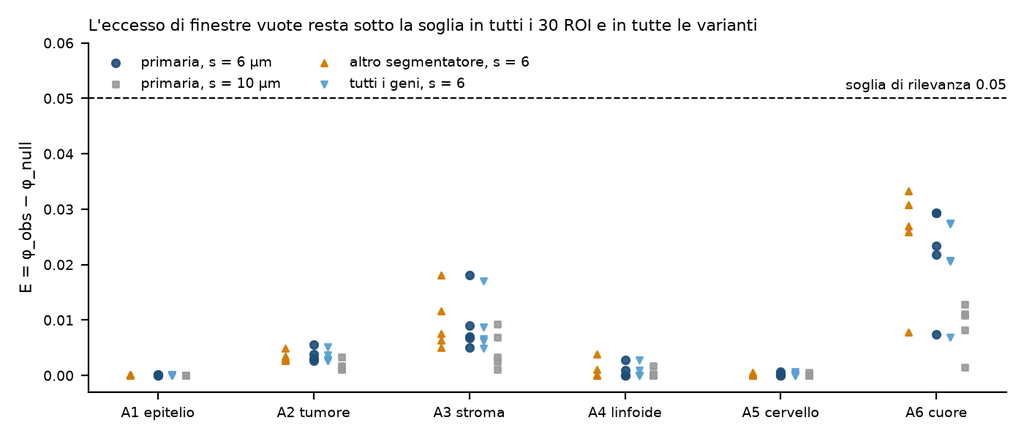

E per ROI e variante. Linea tratteggiata: soglia di rilevanza 0.05 (convenzione).

```r
kable(PR, row.names = FALSE, col.names = c("id", "previsione", "osservato", "esito"))
```

| id | previsione | osservato | esito |
| --- | --- | --- | --- |
| P1 | A4 E piu’ bassa del pannello e E(A4) < 0.05 | E(A4) 0.0000; min altri 0.0000 (parita’) | non valutabile |
| P2 | E(A3) >= 0.05 con verdetto B | E(A3) 0.0070; verdetto nessuno (regola: nessuno) | FAIL |
| P3 | E(A1) <= E(A2) < E(A3) | 0.0000 / 0.0031 / 0.0070 | PASS |
| P4 | A5: A piu’ probabile di B | verdetto nessuno (regola: nessuno) | non valutabile |
| P5 | E(A6) < 0.05, nessun B | E(A6) 0.0234; verdetto nessuno | PASS |

- **P2 smentita**: lo stroma (A3) non mostra vuoto rilevabile.
- **P1 non valutabile**: E(A4) = E(A5) = 0.
- **P3 e P5 passano in modo non informativo**: valori dentro il rumore.
- **P4 non valutabile**: non c’è nessun verdetto di forma.
- **Sensibilità**: altro segmentatore e tutti i geni danno gli stessi verdetti in 6/6 archetipi.

Descrittivo H&E: frazione di tessuto valido oltre d dal nucleo, mediana dei ROI. Non separa citoplasma e matrice (prereg. §2).

```r
h <- aggregate(. ~ archetype, HE[, -2], median); for (j in 2:5) h[[j]] <- f3(h[[j]]); kable(h, row.names = FALSE)
```

| archetype | frac_d>2um | frac_d>4um | frac_d>6um | frac_d>8um |
| --- | --- | --- | --- | --- |
| A1 | 0.563 | 0.367 | 0.245 | 0.161 |
| A2 | 0.444 | 0.256 | 0.146 | 0.084 |
| A3 | 0.643 | 0.469 | 0.327 | 0.213 |
| A4 | 0.160 | 0.035 | 0.007 | 0.001 |
| A5 | 0.842 | 0.758 | 0.672 | 0.584 |
| A6 | 0.935 | 0.874 | 0.798 | 0.709 |

# 4. Controprova

```r
kable(CP, row.names = FALSE, col.names = c("controprova", "arch.", "k", "valore", "esito"))
```

| controprova | arch. | k | valore | esito |
| --- | --- | --- | --- | --- |
| CP-1 | A1 | 3 | 1/5 ROI (R placebo in banda 3/5; BA definita 3/5); R placebo 0.964 (reale 0.697); BA placebo 0.500 (reale 0.500) | FAIL (1/5 ROI) |
| CP-2 | A1 | 3 | 271/7042 finestre vuote (0.038) | FAIL |
| CP-1 | A1 | 5 | 0/5 ROI (R placebo in banda 3/5; BA definita 0/5); R placebo 0.964 (reale 0.697); BA placebo nan (reale nan) | FAIL (0/5 ROI) |
| CP-2 | A1 | 5 | 18/1685 finestre vuote (0.011) | FAIL |
| CP-3 | A1 | NA | s6: E 0.0000 nessuno; s10: E 0.0000 nessuno | PASS |
| CP-1 | A2 | 3 | 3/5 ROI (R placebo in banda 3/5; BA definita 5/5); R placebo 0.966 (reale 0.851); BA placebo 0.538 (reale 0.617) | FAIL (3/5 ROI) |
| CP-2 | A2 | 3 | 1002/4601 finestre vuote (0.218) | FAIL |
| CP-1 | A2 | 5 | 3/5 ROI (R placebo in banda 3/5; BA definita 5/5); R placebo 0.966 (reale 0.851); BA placebo 0.499 (reale 0.590) | FAIL (3/5 ROI) |
| CP-2 | A2 | 5 | 286/1314 finestre vuote (0.218) | FAIL |
| CP-3 | A2 | NA | s6: E 0.0031 nessuno; s10: E 0.0014 nessuno | PASS |
| CP-1 | A3 | 3 | 0/5 ROI (R placebo in banda 0/5; BA definita 5/5); R placebo 0.754 (reale 0.666); BA placebo 0.504 (reale 0.545) | FAIL (0/5 ROI) |
| CP-2 | A3 | 3 | 73/433 finestre vuote (0.169) | FAIL |
| CP-1 | A3 | 5 | 0/5 ROI (R placebo in banda 0/5; BA definita 5/5); R placebo 0.754 (reale 0.666); BA placebo 0.499 (reale 0.534) | FAIL (0/5 ROI) |
| CP-2 | A3 | 5 | 17/105 finestre vuote (0.162) | FAIL |
| CP-3 | A3 | NA | s6: E 0.0070 nessuno; s10: E 0.0033 nessuno | PASS |
| CP-1 | A4 | 3 | 2/5 ROI (R placebo in banda 3/5; BA definita 2/5); R placebo 1.015 (reale 1.086); BA placebo 0.641 (reale 0.794) | FAIL (2/5 ROI) |
| CP-2 | A4 | 3 | 123/321 finestre vuote (0.383) | FAIL |
| CP-1 | A4 | 5 | 1/5 ROI (R placebo in banda 3/5; BA definita 2/5); R placebo 1.015 (reale 1.086); BA placebo 0.620 (reale 0.685) | FAIL (1/5 ROI) |
| CP-2 | A4 | 5 | 22/72 finestre vuote (0.306) | FAIL |
| CP-3 | A4 | NA | s6: E 0.0000 nessuno; s10: E 0.0000 nessuno | PASS |
| CP-1 | A5 | 3 | 0/5 ROI (R placebo in banda 5/5; BA definita 2/5); R placebo 0.953 (reale 0.587); BA placebo 0.541 (reale 0.500) | FAIL (0/5 ROI) |
| CP-2 | A5 | 3 | 1/13147 finestre vuote (0.000) | FAIL |
| CP-1 | A5 | 5 | 0/5 ROI (R placebo in banda 5/5; BA definita 1/5); R placebo 0.953 (reale 0.587); BA placebo 0.500 (reale 0.500) | FAIL (0/5 ROI) |
| CP-2 | A5 | 5 | 0/2871 finestre vuote (0.000) | FAIL |
| CP-3 | A5 | NA | s6: E 0.0000 nessuno; s10: E 0.0000 nessuno | PASS |
| CP-1 | A6 | 3 | 4/5 ROI (R placebo in banda 5/5; BA definita 5/5); R placebo 0.987 (reale 0.626); BA placebo 0.529 (reale 0.555) | FAIL (4/5 ROI) |
| CP-2 | A6 | 3 | 2281/5101 finestre vuote (0.447) | FAIL |
| CP-1 | A6 | 5 | 4/5 ROI (R placebo in banda 5/5; BA definita 5/5); R placebo 0.987 (reale 0.626); BA placebo 0.516 (reale 0.553) | FAIL (4/5 ROI) |
| CP-2 | A6 | 5 | 533/1033 finestre vuote (0.516) | FAIL |
| CP-3 | A6 | NA | s6: E 0.0234 nessuno; s10: E 0.0108 nessuno | PASS |

- **CP-1 placebo (nuclei traslati di 30–60 µm), esito pre-registrato per ROI** (R placebo in [0.9, 1.1] **e** BA placebo < BA reale):
  - passa in A6 4/5, A2 3/5, A4 2/5, A1 1/5, A3 0/5, A5 0/5;
  - in A5 la causa è che la BA non è definita (quasi nessuna finestra vuota), mentre R placebo è in banda 5/5;
  - la condizione congiunta era mal posta quando la BA non è definita: è un errore di pre-registrazione.
- **Lettura su R** (post hoc, revisione M-05/M-06):
  - il confronto giusto è con R sotto il nullo, non con 1;
  - in A5 e A6 R osservato (0.59, 0.63) è molto sotto il nullo (0.90, 0.98) e il placebo lo riporta a ~1;
  - il revisore lo trova stabile anche con i soli bin a ≥ 20 µm dai bordi e a parità di territorio;
  - in A1–A3 R osservato ≈ R nullo: il calo con la distanza è prodotto dai territori e dai bordi, non da un gradiente legato al nucleo;
  - in A3 cala anche col placebo.
- **CP-2 vuoto vero: FAIL in tutti gli archetipi.** I bin `in_tissue = 1` fuori dalla maschera R2 risultano vuoti da 0 (A5) a 0.52 (A6, s = 10). Cosa sono questi bin (PH-4, M-08, M-09):
  - **A1–A4**: lumi o tessuto adiposo veri, quindi il test è valido e smentisce la capacità della misura;
  - **A5**: neuropilo escluso dalla maschera, quindi il test non è valido;
  - **A6**: misto, con tessuto pallido in r1, r2 e vuoti veri in r3–r5.
- **CP-3 scala**: PASS 6/6, banalmente (tutto «nessuno»).

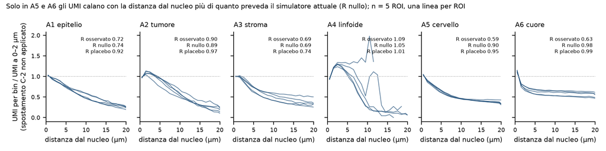

UMI per bin in funzione della distanza dal nucleo, normalizzati al valore a 0–2 µm; una linea per ROI. R = UMI a 4–8 µm / 0–2 µm; R nullo = stesso rapporto dopo la permutazione dentro il territorio (simulatore attuale).

# 5. Analisi post hoc

**PH-1, livelli nei lumi.**

```r
a <- aggregate(cbind(umi_tissue_mean, umi_lumen_mean, umi_bg_far_per_bin, lumen_frac_roi) ~ archetype, PH1, median); for (j in 2:5) a[[j]] <- f3(a[[j]])
kable(a, row.names = FALSE, col.names = c("arch.", "UMI/bin tessuto", "UMI/bin «lume»", "UMI/bin vetro ≥ 50 µm", "frazione del ROI «lume»"))
```

| arch. | UMI/bin tessuto | UMI/bin «lume» | UMI/bin vetro ≥ 50 µm | frazione del ROI «lume» |
| --- | --- | --- | --- | --- |
| A1 | 29.700 | 6.075 | 0.197 | 0.082 |
| A2 | 50.595 | 5.219 | 0.447 | 0.025 |
| A3 | 20.937 | 4.526 | 0.447 | 0.004 |
| A4 | 11.814 | 2.815 | 0.043 | 0.004 |
| A5 | 45.311 | 25.105 | 0.411 | 0.124 |
| A6 | 3.250 | 1.433 | 0.221 | 0.062 |

A 16–32 µm dal bordo i lumi di A1–A4 stanno 4.41–10.86 volte sopra il vetro lontano (mediane per archetipo; ROI 3.08–18.65). Negli altri due archetipi il rapporto non misura un vuoto vero: in A5 vale 42.07 (il «lume» è neuropilo escluso dalla maschera); in A6 vale 0.75, cioè i vuoti veri di r3–r5 scendono **sotto** il livello del vetro lontano, ed è per questo che CP-2 in A6 regge in parte (0.45–0.52 di finestre vuote). Il revisore ha verificato due cose (M-10; `results/S1.3c/review/method/out/lumen_vs_exterior_profile.csv`): - il vetro **esterno** alla stessa distanza dal tessuto ha anch’esso UMI sopra il vetro lontano, quindi c’è una coda lunga di diffusione che la soglia pre-registrata esclude per costruzione; - i lumi, circondati dal tessuto, ne ricevono di più.

Il contenuto dei lumi (muco) non è escluso, ma non è visibile in H&E.

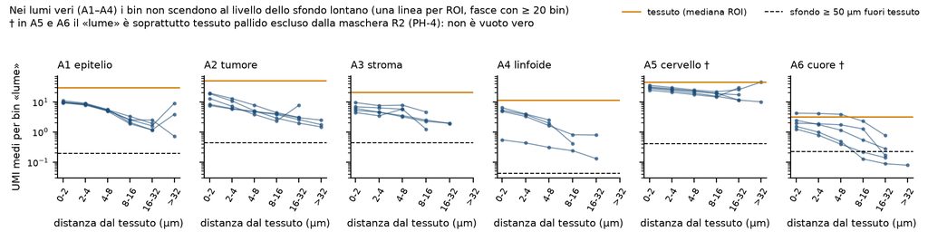

Profilo dei lumi.

**PH-3, calibrazione di E** (vuoto sintetico perfetto, 5 ROI per archetipo; recupero = E / frazione azzerata, mediana):

```r
w <- reshape(rec, idvar = c("archetype", "type"), timevar = "f_target", direction = "wide"); for (j in 3:6) w[[j]] <- f3(w[[j]])
m <- merge(w, PH3m, by = c("archetype", "type"), all.x = TRUE); m$f_min_detectable[is.na(m$f_min_detectable)] <- "> 0.30"
kable(m, row.names = FALSE, col.names = c("arch.", "tipo", "recupero 5 %", "10 %", "20 %", "30 %", "frazione minima con E ≥ 0.05"))
```

| arch. | tipo | recupero 5 % | 10 % | 20 % | 30 % | frazione minima con E ≥ 0.05 |
| --- | --- | --- | --- | --- | --- | --- |
| A1 | A | 0.504 | 0.468 | 0.450 | 0.454 | 0.2 |
| A1 | B | 0.436 | 0.432 | 0.433 | 0.432 | 0.2 |
| A2 | A | 0.461 | 0.439 | 0.434 | 0.422 | 0.2 |
| A2 | B | 0.540 | 0.500 | 0.476 | 0.459 | 0.1 |
| A3 | A | 0.795 | 0.688 | 0.626 | 0.560 | 0.1 |
| A3 | B | 0.705 | 0.627 | 0.530 | 0.472 | 0.1 |
| A4 | A | 0.111 | 0.118 | 0.110 | 0.096 | > 0.30 |
| A4 | B | 0.254 | 0.256 | 0.265 | 0.268 | 0.2 |
| A5 | A | 0.867 | 0.771 | 0.706 | 0.692 | 0.1 |
| A5 | B | 0.727 | 0.673 | 0.662 | 0.634 | 0.1 |
| A6 | A | 0.973 | 0.729 | 0.613 | 0.549 | 0.1 |
| A6 | B | 0.929 | 0.668 | 0.491 | 0.412 | 0.1 |

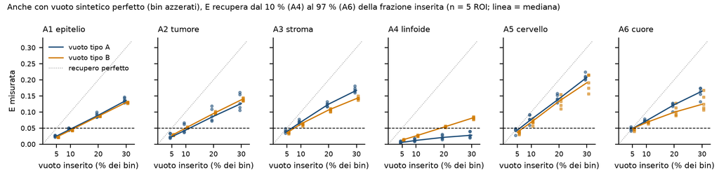

Calibrazione di E contro la frazione vuota inserita.

**PH-4, ispezione visiva** (ritagli di 250 µm; contorno della maschera R2 in ciano; bin «lume» colorati per UMI):

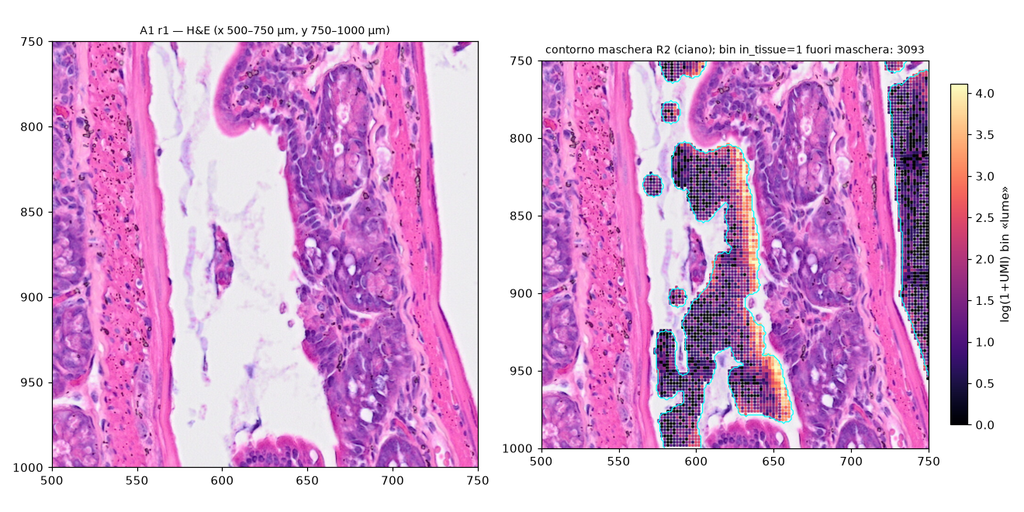

A1 r1: lume intestinale vero; bin luminosi lungo l’epitelio, più scuri al centro.

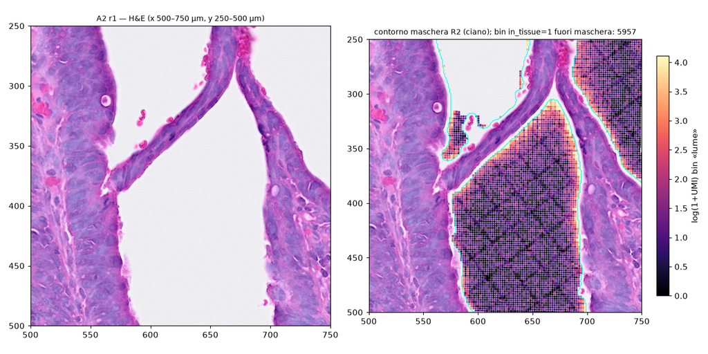

A2 r1: lume ghiandolare vero; reticolo diagonale periodico nei conteggi (osservato, non interpretato).

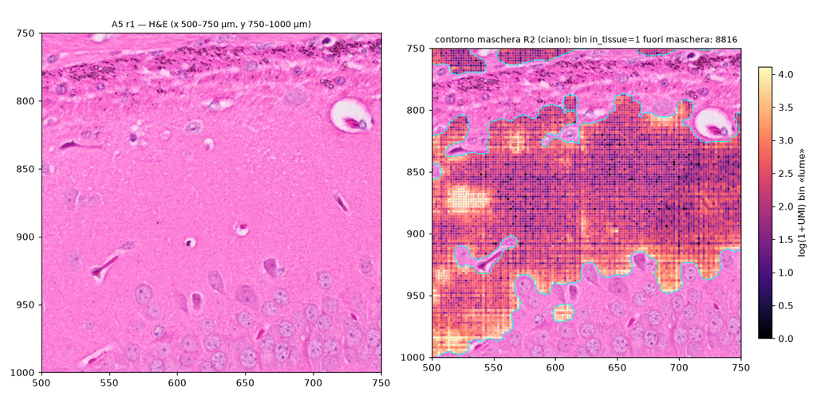

A5 r1: la maschera esclude neuropilo pallido fra gli strati di somi, con UMI a livello di tessuto.

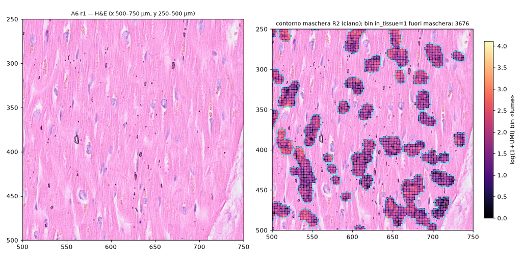

A6 r1: la maschera esclude chiazze pallide di miocardio (in r3–r5 i bin esclusi sono invece vuoti veri).

# 6. Che cosa decidere

- **Decisione 1 del design**: resta com’è, per difetto. I conteggi a 2 µm non bastano per dire se c’è matrice fra le cellule. Per riaprire BL-077 servono una stima della diffusione (R5) e una soglia locale, oppure un’annotazione istologica della matrice per archetipo.
- **Per S1.4**: in A5 e A6 i dati smentiscono la densità di RNA uniforme nel territorio. Un profilo radiale (più RNA vicino al nucleo) va misurato e calibrato con `derive_cell_geometry()`. In A1–A3 non c’è evidenza oltre il simulatore attuale.
- **Per R2/R3**: la maschera di tessuto esclude tessuto pallido in A5/A6 (BACKLOG).

# Verdetto

- **Stato: non chiusa.** La misura pre-registrata è stata eseguita, verificata (check C, C-6, due revisori) e calibrata. La sua controprova (CP-2) e la calibrazione mostrano che non può rispondere alla domanda. La raccomandazione formale C non è sostenuta. BL-077 resta aperta.
- **Risultati utilizzabili**:
  - limite di rilevazione dei conteggi a 2 µm;
  - gradiente nucleo → periferia oltre il nullo in A5 e A6;
  - difetto della maschera R2;
  - coda di diffusione oltre il bordo del tessuto (dato per R5).
- **Errori di pre-registrazione**: C-3 (insiemi di geni), CP-1 (condizione con BA non definita), soglia di vuoto non raggiungibile dentro il tessuto, P1 senza regola per la parità.

# Revisione avversariale

Due revisori indipendenti, entrambi sul server (`results/S1.3c/review/recalc/README.md`, `results/S1.3c/review/method/README.md`).

- **«Ricalcolo»**: codice proprio. Sfondo, C-3 e UMI identici in 5/5 dataset; 141/141 grandezze deterministiche identiche; nullo ed E entro la variabilità dei seed; controllo positivo riprodotto.
- **«Metodo»**: codice, pre-registrazione, numeri del report e interpretazioni alternative, con analisi proprie (bordi, nullo, maschere, alone esterno, registrazione ±30 µm).

Rilievi: 27 (2 bug, 5 discrepanze, 11 di metodo, 9 confermati); tutti con azione:

```r
kable(RA, row.names = FALSE)
```

| id | revisore | classe | rilievo | azione |
| --- | --- | --- | --- | --- |
| RC-1 | Ricalcolo | confermato | UMI per bin / C-3 / soglie di sfondo identici in 5/5 dataset | nessuna |
| RC-2 | Ricalcolo | bug | mappatura bin->maschere ds4 con side_um/913 invece di 4 px nativi (<= 0.55 um; \|dE\| <= 1.6e-4) | corretto (ds4_index) e rieseguito; verdetti invariati |
| RC-3 | Ricalcolo | confermato | 141/141 grandezze deterministiche dei 6 ROI identiche | nessuna |
| RC-4 | Ricalcolo | confermato | phi_null ed E entro la variabilita’ di seed (\|z\| <= 2.2) | nessuna |
| RC-5 | Ricalcolo | confermato | controllo positivo A3 r1 E 0.0688; C5 typeA e PH-3 f=0.10 sono lo stesso numero | nel report non presentati come conferme distinte |
| RC-6 | Ricalcolo | metodo | convenzione floor dei pixel non dichiarata (effetto <= 0.004 su R) | dichiarata (note punto 25) |
| RC-7 | Ricalcolo | metodo | BA instabile con poche finestre vuote | n ROI con BA definita riportato; nessuna soglia minima (sarebbe post hoc) |
| M-01 | Metodo | bug | conteggio CP-1 fermo a 1 (somma di numpy.bool_ in colonna object) | corretto con test (analysis –test 8/8); A6 4/5 A2 3/5 A4 2/5 |
| M-02 | Metodo | metodo | spostamento ottimo di C-2 non applicato come pre-registrato | applicato a BA r* R CP-1 nei ROI con C-2 FAIL; riportati anche i valori senza |
| M-03 | Metodo | metodo | C-5a operativo diverge dalla pre-registrazione ed e’ quasi tautologico | dichiarato nel report; con la definizione letterale FAIL 6/6 |
| M-04 | Metodo | metodo | C-5b circolare (vuoto A definito con la stessa d_nuc del modello A) | dichiarato come limite del criterio di forma |
| M-05 | Metodo | discrepanza | gradiente in A1 non legato ai nuclei; confronto con 1 sbagliato | R nullo aggiunto; gradiente oltre il nullo solo in A5 e A6 |
| M-06 | Metodo | confermato | gradiente in A5 e A6 robusto a bordi e composizione dei territori | riportato |
| M-07 | Metodo | metodo | CP-1 riletto solo su R (post hoc) | esito pre-registrato per archetipo riportato; lettura su R etichettata post hoc |
| M-08 | Metodo | confermato | maschera R2 esclude tessuto pallido in A5 (luminosita’ > 0.97) | meccanismo nel report; BACKLOG |
| M-09 | Metodo | discrepanza | in A6 tessuto pallido escluso solo in r1 r2; r3-r5 vuoti veri | corretto nel report |
| M-10 | Metodo | metodo | nessun plateau: coda di diffusione lunga presente anche sul vetro esterno | lettura corretta nel report |
| M-11 | Metodo | discrepanza | rapporto 4-13x non riproducibile | sostituito con mediane per archetipo e intervallo per ROI |
| M-12 | Metodo | discrepanza | tre frasi imprecise su C-2/PH-2 | corrette |
| M-13 | Metodo | discrepanza | mutante C-4 permuta i bin validi non tutto il ROI | testo allineato al codice |
| M-14 | Metodo | metodo | BA mediana sui soli ROI con BA definita | dichiarato; n riportato |
| M-15 | Metodo | metodo | analysis.py scritto durante il run e committato dopo | dichiarato; test aggiunti |
| M-16 | Metodo | metodo | P1 passa per parita’ | P1 non valutabile |
| M-17 | Metodo | metodo | stato chiusa con riserve generoso | stato: non chiusa |
| M-18 | Metodo | confermato | E phi_obs phi_null ricalcolati indipendentemente coincidono | nessuna |
| M-19 | Metodo | confermato | altri numeri del report coincidono con i CSV | nessuna |
| M-20 | Metodo | confermato | nessun bug in ecm.py; cronologia coerente | nessuna |

# Riproducibilità

```bash
cd ~/2025.geo_spatialtrans && git checkout <sha di chiusura nella nota di sessione>
.venv/bin/python R/testing/test_S1.3c.py && .venv/bin/python tools/S1.3c_analysis.py --test
.venv/bin/python tools/S1.3c_ecm.py all          # umi -> roi -> ctrl, uscite in /mnt/micron/geo_spatialtrans/S1.3c
.venv/bin/python tools/S1.3c_analysis.py && .venv/bin/python tools/S1.3c_posthoc.py all && .venv/bin/python tools/S1.3c_figures.py
quarto render reports/S1.3c.qmd
```